# methyTools - EWAS meta-analysis example

26 octubre 2020

#### Package

methyTools 0.1.0

# 1 Prerequisites

The package requires other packages to be installed. These include: `ggplot2`, `VennDiagram`, `RColorBrewer`, `tibble`, `dplyr`, `stringr`, `rasterpdf` and `meta` all available in CRAN. The package also requires other packages from Bioconductor to perform annotations : `IlluminaHumanMethylation450kanno.ilmn12.hg19` and `IlluminaHumanMethylationEPICanno.ilm10b4.hg19`.

To perform meta-analyses we use GWAMA, a Software tool for meta analysis developed by Intitute of Genomics from University of Tartu, this software is available at https://genomics.ut.ee/en/tools/gwama-download, this software must be installed on the computer where we are running analysis (already installed in machines 05 and 06 from ISGlobal Campus Mar).

# 2 Overview

In this vignette we will show how to perform an epigenetic wide-association study (EWAS) analysis. As an example we will perform an EWAS analysis with three different cohorts and two distinct models for each cohort

# 3 Getting started

First, we need to install and load the required packages

```r
if (!require(rasterpdf, quietly = TRUE))
   install.packages('rasterpdf', repos = 'https://cran.rediris.es/' )
if (!require(meta, quietly = TRUE))
   install.packages('meta', repos = 'https://cran.rediris.es/' )
if (!require(ggplot2, quietly = TRUE)) install.packages('ggplot2')
if (!require(VennDiagram, quietly = TRUE))
   install.packages('VennDiagram')
if (!require(ellipsis, quietly = TRUE))
   install.packages('ellipsis')
if (!require(RColorBrewer, quietly = TRUE))
   install.packages('RColorBrewer')
if (!require(tibble, quietly = TRUE))
   install.packages('tibble')
if (!require(dplyr, quietly = TRUE))
   install.packages('dplyr')
if (!require(stringr, quietly = TRUE))
   install.packages('stringr')
if (!require(readtext, quietly = TRUE))
   install.packages('readtext')
if (!require(meta, quietly = TRUE))
   install.packages('meta') # Forest Plot
if (!requireNamespace("BiocManager", quietly = TRUE))
   install.packages("BiocManager")
if (!require(missMethyl, quietly = TRUE))
   BiocManager::install( "missMethyl" )
if (!require(org.Hs.eg.db, quietly = TRUE))
   BiocManager::install( "org.Hs.eg.db" )
if (!require(GenomicRanges, quietly = TRUE))
   BiocManager::install( "GenomicRanges" )
if (!require(rtracklayer, quietly = TRUE))
   BiocManager::install( "rtracklayer" )

# BiocManager::install( c("IlluminaHumanMethylation450kanno.ilmn12.hg19",
#                         "IlluminaHumanMethylation450kanno.ilmn12.hg19",
#                         "missMethyl",
#                         "org.Hs.eg.db",
#                         "GenomicRanges",
#                         "rtracklayer") )
```

The development version of `methyTools` package can be installed from BRGE GitHub repository:

```r
devtools::install_github("isglobal-brge/methyTools@HEAD")
```

```r
library(methyTools)
library(readtext)
```

# 4 Quality control

## 4.1 Initial Variables definition

We need to define the variables to work with, and the files containing the data to perform the analysis.

### 4.1.1 Input data

As we commented before, we will perform an EWAS with three different cohorts and two distinct models for each cohort, so we need to define where the data is stored for each model and each cohort (six files). We do that in a character vector, and the variable is called files:

```r
files <- c('data/PACE_AQUA_Model1_date_v2.txt',
           'data/PACE_AQUA_Model2_date_v2.txt',
           'data/PACE_INMA_Plate_ModelA1_20170309.txt',
           'data/PACE_INMA_Plate_ModelA2_20170309.txt',
           'data/RICHS_Model1_20170713.txt',
           'data/RICHS_Model2_20170713.txt')
```

files must contain at least the fields :

| probeID | BETA | SE | P_VAL |
| --- | --- | --- | --- |
| cg13869341 | 0.00143514362777834 | 0.00963411132344512 | 0.678945643213567 |
| cg24669183 | -0.0215342789035512 | 0.0150948404044624 | 0.013452341234512 |
| cg15560884 | 0.00156725345562218 | 0.0063878467810596 | 0.845523221223523 |

### 4.1.2 Where to store output

We can also define the folder where we will save the results, for example in a variable called `result_folder`, in this case the results will be stored under QC_Results folder.

```r
# Result folder
results_folder <- 'QC_Results'
```

### 4.1.3 Make results understandable

To make the analysis more understandable and do not have very complex file names we can define an abbreviated form for each of the files defined above. For example, PACE_AQUA_Model1_date_v2 will be treated as PACE_AQUA_A1 or PACE_INMA_Plate_ModelA2_20170309 as PACE_IMMA_A2. The length of the prefix vector must be equal to that of the files:

```r
# Prefixes for each file
prefixes <- c('PACE_AQUA_A1', 'PACE_AQUA_A2',
              'PACE_IMMA_A1','PACE_IMMA_A2',
              'RICHS_A1', 'RICHS_A2')
```

### 4.1.4 Illumina Array type and filter conditions

We need to know the Illumina array type, possible values are 450K and EPIC. This information is very important because we filter CpGs according to Illumina array type:

```r
# Array type, used : EPIC or 450K
artype <- '450K'
```

In quality control (QC) process, we exclude those CpGs that do not accomplish the defined parameters (based on *Zhou et al. 2017, Solomon et al. 2018, Fernandez-Jimenez et al. 2019*). These parameters are defined in a character vector and are the following:

- **MASK_sub25_copy** : indicate whether the 25bp 3’-subsequence of the probe is non-unique. The sequence of the last 25bp at the 3’ end of the probe is non-unique (problematic because the beta value of such probes is more likely to represent a combination of multiple sites and not the level of initially targeted CpG sites), based on Zhou et al. (2017).
- **MASK_sub30_copy** : : indicate whether the 30bp 3’-subsequence of the probe is non-unique. The sequence of the last 30bp at the 3’ end of the probe is non-unique (problematic because the beta value of such probes is more likely to represent a combination of multiple sites and not the level of initially targeted CpG sites), based on *Zhou et al. (2017)*. In the paper they recommend 30bp, but in the code we prepared we have the possibility to adapt this to probes with non-unique 25bp, or 35bp, or 40bp, or 45bp 3’-subsequence.
- **MASK_sub35_copy** : indicate whether the 35bp 3’-subsequence of the probe is non-unique. The sequence of the last 35bp at the 3’ end of the probe is non-unique (problematic because the beta value of such probes is more likely to represent a combination of multiple sites and not the level of initially targeted CpG sites), based on *Zhou et al. (2017)*. In the paper they recommend 30bp, but in the code we prepared we have the possibility to adapt this to probes with non-unique 25bp, or 35bp, or 40bp, or 45bp 3’-subsequence.
- **MASK_sub40_copy** : indicate whether the 40bp 3’-subsequence of the probe is non-unique. The sequence of the last 40bp at the 3’ end of the probe is non-unique (problematic because the beta value of such probes is more likely to represent a combination of multiple sites and not the level of initially targeted CpG sites), based on *Zhou et al. (2017)*. In the paper they recommend 30bp, but in the code we prepared we have the possibility to adapt this to probes with non-unique 25bp, or 35bp, or 40bp, or 45bp 3’-subsequence.
- **MASK_mapping** : "hether the probe is masked for mapping reason. Probes retained should have high quality (>=40 on 0-60 scale) consistent (with designed MAPINFO) mapping (for both in the case of type I) without INDELs. Probes that have poor quality mapping to the target genomic location as indicated in the array’s manifest file based on genome build GRCh37 and GRCh38 (for example due to the presence of INDELs - INDELs are Insertion–deletion mutations present in the genome, and like SNPs are of great interest because they can alter human traits and can cause human diseases-), based on *Zhou et al. (2017)*.
- **MASK_extBase** : Probes masked for extension base inconsistent with specified color channel (type-I) or CpG (type-II) based on mapping. Probes with a SNP altering the CpG dinucleotide sequence context and hence the ability of target cytosines to be methylated. This also includes the special case where an actual C/T polymorphism is present instead of C/T difference introduced by bisulfite conversion (the extension base is inconsistent with the specified color channel (type-I) or CpG (type-II) according to mapping, based on *Zhou et al. (2017)*.
- **MASK_typeINextBaseSwitch** : Whether the probe has a SNP in the extension base that causes a color channel switch from the official annotation (described as color-channel-switching, or CCS SNP in the reference), based on *Zhou et al. 2017*.
- **MASK_snp5.common** : Whether 5bp 3’-subsequence (including extension for typeII) overlap with any of the common SNPs from dbSNP (global MAF can be under 1%), based on Zhou et al. 2017.
- **MASK_snp5.GMAF1p** : Whether 5bp 3’-subsequence (including extension for typeII) overlap with any of the SNPs with global MAF >1%, based on Zhou et al. 2017.
- **MASK_general** : Recommended general purpose masking merged from *“MASK.sub30.copy”, “MASK.mapping”, “MASK.extBase”, “MASK.typeINextBaseSwitch” and “MASK.snp5.GMAF1p”*, based on *Zhou et al. 2017*.
- **cpg_probes** : cpg probes classified as “cg” in the variable named “probeType”.
- **noncpg_probes** : non-cpg probes classified as “ch” in the variable named “probeType”.
- **control_probes** : control probes classified as “rs” in the variable named “probeType”.
- **Unreliable_450_EPIC** : Unreliable probes discordant between 450K and EPIC in blood, based on *Solomon et al. 2018*.
- **Unreliable_450_EPIC_Pla**: Unreliable probes discordant between 450K and EPIC in plaenta, based on *Fernandez-Jimenez et al. 2019*.
- **Sex** : Keep probes targeting cpgs from sex chromosomes “chrX” and “chrY”. ( CpG_chrm %in% “chrX” & CpG_chrm %in% “chrY” )

In this example we exclude CpGs that meet condition : MASK_sub35_copy, MASK_typeINextBaseSwitch, noncpg_probes, control_probes, Unreliable_450_EPIC and Sex.

```r
# Parameters to exclude CpGs
exclude <- c( 'MASK_sub35_copy',
              'MASK_typeINextBaseSwitch',
              'noncpg_probes',
              'control_probes',
              'Unrel_450_EPIC_blood',
              'Sex')
```

We also need to define the ethnic, ethnic can be : EUR SAS AMR GWD YRI TSI IBS CHS PUR JPT GIH CH_B STU ITU LWK KHV FIN ESN CEU PJL AC_B CLM CDX GBR BE_B PEL MSL MXL ASW or GMAF1p if population is very diverse.

```r
ethnic <- 'EUR'
```

### 4.1.5 Other variables :

To obtain the precision plot or perform the GWAMA meta-analysis we need to know the number of samples in our data, so we store this information in ”N”, defining the sample size for each of the files. The n array is similar to N but in that case we define the size of a dichotomous variable for example smoke.

```r
N <- c(100, 100, 166, 166, 240, 240 )
n <- c(NA)
```

## 4.2 QC - Numerical analysis code

This code can be executed for each file defined in previous variable `files` but in this example we only show the analysis workflow for a simple file.

```r
# Variable declaration to perform precision plot
medianSE <- numeric(length(files))
value_N <- numeric(length(files))
cohort_label <- character(length(files))

# Prepare output folder for results (create if not exists)
if(!dir.exists(file.path(getwd(), results_folder )))
   suppressWarnings(dir.create(file.path(getwd(), results_folder)))


# IMPORTANT FOR A REAL ANALYSIS :

# To show the execution flow we perform the analysis with only one data
# file. Normally, we have more than one data file to analyze, for that
# reason, we execute the code inside a loop and we follow the execution
# flow for each file defined in `files`
# So we need to uncomment the for instruction and remove i <- 1 assignment.

# for ( i in 1:length(files) )
# {

   # we force i <- 1 to execute the analysis only for the first variable
   # for real data we have to remove this line
   i <- 1
```

First, we need to read the content of a file,

```r
# Read data.
cohort <- read.table(files[i], header = TRUE, as.is = TRUE)
print(paste0("Cohort file : ",files[i]," - readed OK", sep = " "))
```

```
## [1] "Cohort file : data/PACE_AQUA_Model1_date_v2.txt - readed OK "
```

and store the content of the file in a `cohort` variable. After that, we perform a simple descriptive analysis, using the function `descriptives_CpGs`. This function needs the data to analyze (`cohort`), the fields for which we are interested to get descriptives, ( BETA, SE and P_VAL (seq(2:4))), and a file name to write results. For the first file it would be: *QC_Results/PACE_AQUA_A1_descriptives_init.txt*

```r
# Descriptives - Before CpGs deletion
descriptives_CpGs(cohort, seq(2,4), paste0(results_folder,'/',prefixes[i],
                                           '_descriptives_init.txt') )
```

Then, we test if there are any duplicate CpGs. If there are duplicated CpGs, these are removed using the function `remove_duplicate_CpGs`. In this function we must indicate what data have to be reviewed and the field that contains the CpG IDs. Optionally, we can write the duplicates and descriptives related to this duplicates in a file.

```r
# Remove duplicates
cohort <- remove_duplicate_CpGs(cohort, "probeID",
                                paste0(results_folder,'/',prefixes[i],
                                       '_descriptives_duplic.txt'),
                                paste0(results_folder,'/',prefixes[i],
                                       '_duplicates.txt') )
```

To exclude CpGs that we are not interested in, we use the function `exclude_CpGs`. Here we use the parameters defined before in exclude variable, which are the data, cohort, the CpG id field (can be the column number or the field name “probeId”), the filters to apply defined in `exclude` variable, and, optionally, a file name if we want to save excluded CpGs and the exclusion reason (in this case the file name will be *QC_Results/PACE_AQUA_A1_excluded.txt*).

```r
# Exclude CpGs not meet conditions
cohort <- exclude_CpGs(cohort, "probeID", exclude,
                       filename = paste0(results_folder,'/',prefixes[i],
                                         '_excluded.txt') )
```

After eliminating the inconsistent CpGs, we proceed to carry out another descriptive analysis,

```r
# Descriptives - After CpGs deletion #
descriptives_CpGs(cohort, seq(2,4),
                  paste0(results_folder,'/',prefixes[i],
                         '_descriptives_last.txt') )
```

Now, we can get adjusted p-values by Bonferroni and FDR. The function to adjust data is `adjust_data`, and we have to indicate in which column the p-value is and what adjustment we want. By default the function adjust data by Bonferroni (`bn`) and FDR (`fdr`). This function, returns the input data with two new columns corresponding to these adjustments. As in other functions seen before, optionally, we can get a data summary with the number of significative values with bn, fdr, …. in a text file, (the generated file in the example is called *QC_Results/PACE_AQUA_A1_ResumeSignificatives.txt* ).

```r
# data before adjustment
head(cohort)
```

```
##      probeID          BETA          SE     P_VAL CpG_chrm CpG_beg CpG_end
## 1 cg00002593 -0.0014173332 0.010439809 0.8920091     chr1 1333412 1333414
## 2 cg00009834 -0.0001004819 0.007697701 0.9895851     chr1 1412290 1412292
## 3 cg00014118 -0.0063691442 0.016149771 0.6933006     chr1 2004121 2004123
## 4 cg00040588  0.0010886197 0.013553046 0.9359805     chr1 1355331 1355333
## 5 cg00060374 -0.0178768165 0.030803617 0.5616800     chr1 1419854 1419856
## 6 cg00078456 -0.0104996986 0.008940391 0.2402302     chr1 1629041 1629043
##   MASK_snp5_EUR probeType Unrel_450_EPIC_blood MASK_mapping
## 1         FALSE        cg                FALSE        FALSE
## 2         FALSE        cg                FALSE        FALSE
## 3         FALSE        cg                FALSE        FALSE
## 4         FALSE        cg                FALSE        FALSE
## 5         FALSE        cg                FALSE        FALSE
## 6         FALSE        cg                FALSE        FALSE
##   MASK_typeINextBaseSwitch MASK_rmsk15 MASK_sub40_copy MASK_sub35_copy
```

[output cut: 20 more lines]

```r
# Adjust data by Bonferroni and FDR
cohort <- adjust_data(cohort, "P_VAL", bn=TRUE, fdr=TRUE,
                      filename =  paste0(results_folder,'/',prefixes[i],
                                         '_ResumeSignificatives.txt')  )

# data after adjustment
head(cohort)
```

```
##         probeID        BETA          SE        P_VAL CpG_chrm CpG_beg CpG_end
## 609  cg10983617 -0.06967961 0.019136276 0.0002713369     chr1 1043283 1043285
## 409  cg07426077  0.01715768 0.004776728 0.0003282363     chr1 1553200 1553202
## 181  cg03538326 -0.02123421 0.006503119 0.0010937309     chr1 1440464 1440466
## 128  cg02630349 -0.05958242 0.018518028 0.0012929693     chr1 1043286 1043288
## 954  cg16679343 -0.02148449 0.006807270 0.0015988857     chr1 1117568 1117570
## 1018 cg17801765 -0.03068740 0.009899132 0.0019351477     chr1 1022893 1022895
##      MASK_snp5_EUR probeType Unrel_450_EPIC_blood MASK_mapping
## 609          FALSE        cg                FALSE        FALSE
## 409          FALSE        cg                FALSE        FALSE
## 181          FALSE        cg                FALSE        FALSE
## 128          FALSE        cg                FALSE        FALSE
## 954          FALSE        cg                FALSE        FALSE
## 1018         FALSE        cg                FALSE        FALSE
##      MASK_typeINextBaseSwitch MASK_rmsk15 MASK_sub40_copy MASK_sub35_copy
```

[output cut: 27 more lines]

We are ready to write the data into a file with the `write_QCData` function. The file generated by this function is very important for the next steps, to generate GWAMA files. This data is stored with *_QC_Data.txt* sufix. In this function data is annotated before being written to the file,

```r
   # Write QC complete data to external file
   write_QCData(cohort, paste0(results_folder,'/',prefixes[i]))
```

## 4.3 QC - Graphical analysis code

To perform a graphical analysis we have different functions. We can easily generate a SE or p-value distribution plots with `plot_distribution` function

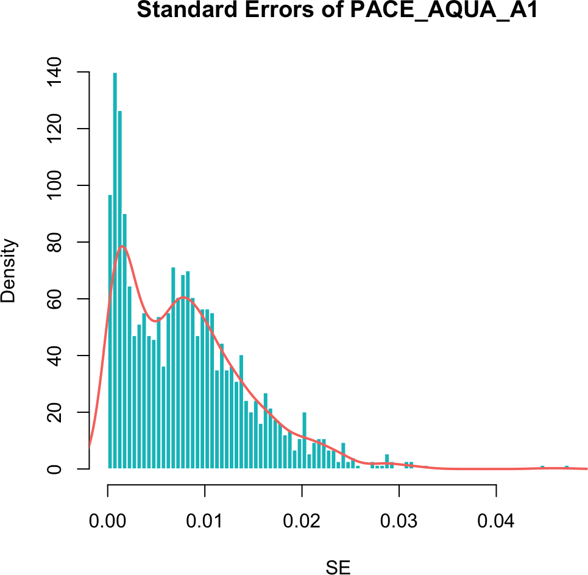

Figure 1: SE distribution plot

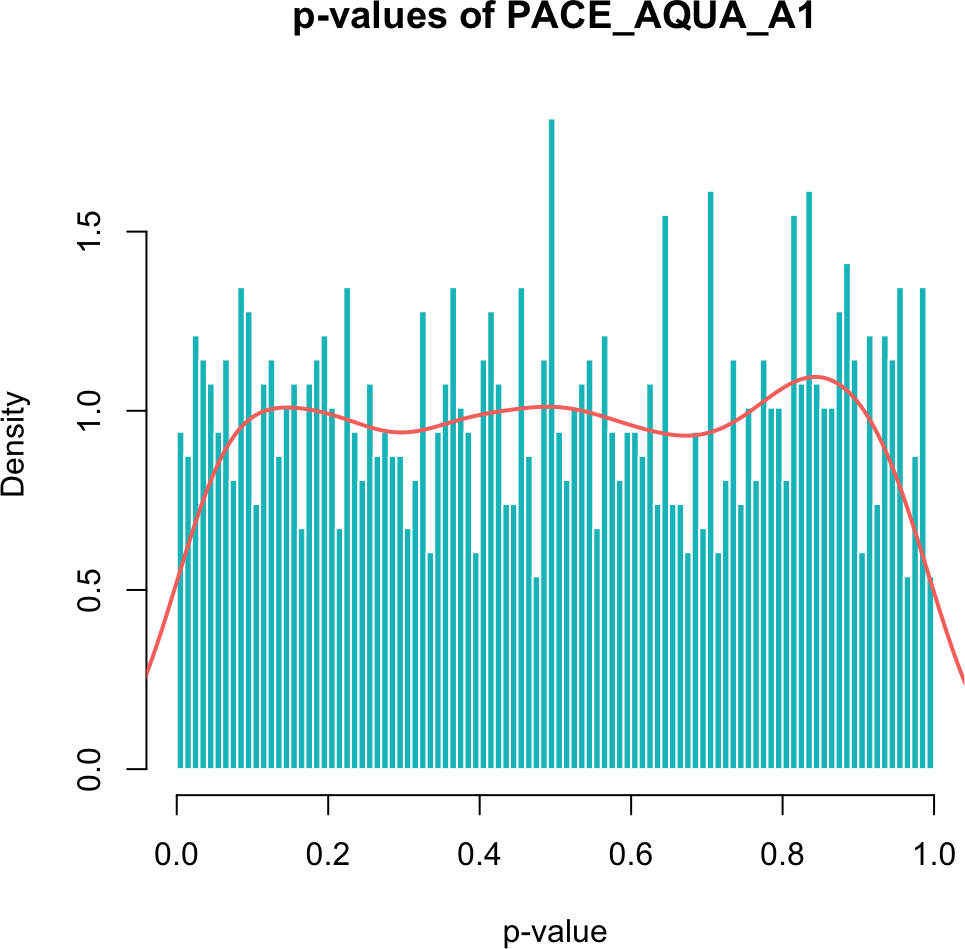

Figure 2: p-value distribution plot

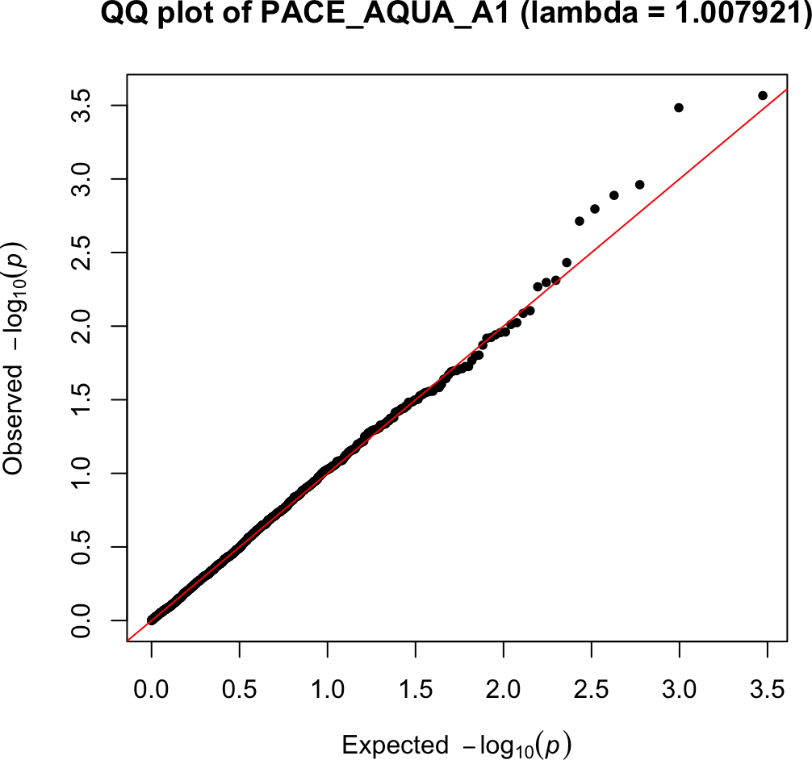

Figure 3: QQplot

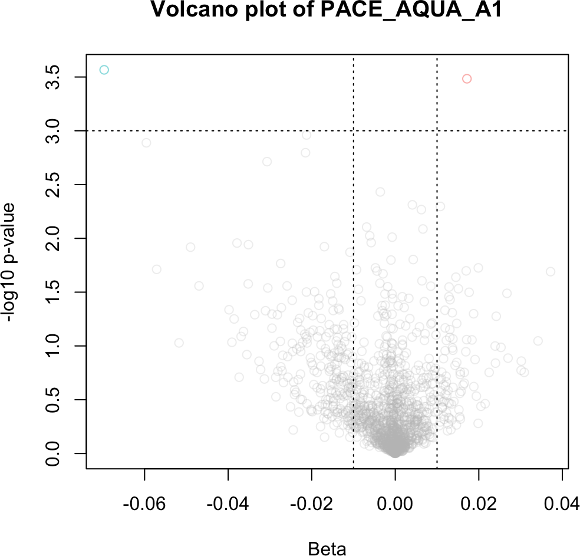

Figure 4: Volcano Plot

When we have the results for all models and cohorts, we can perform a Precision plot with `plot_precisionp` function

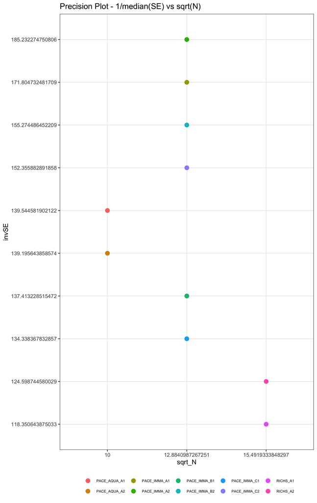

Figure 5: Precision plot for 10 different datasets

Venn diagrams are obtained with function `plot_venndiagram`,. We need to define the venn diagram for a maximum of 5 datasets. Here we define which models and cohorts we want to be shown in the Venn diagram. In this example we define two different Venn diagrams, one with “PACE_AQUA_A1”, “PACE_IMMA_A1” and “RICHS_A1” datasets and the other with three more datasets “PACE_AQUA_A2”, “PACE_IMMA_A2” and “RICHS_A2”

```r
# Venn diagrams
venn_diagrams <- list(
   c("PACE_AQUA_A1", "PACE_IMMA_A1", "RICHS_A1" ),
   c("PACE_AQUA_A2", "PACE_IMMA_A2", "RICHS_A2" )
)
```

# 5 Meta-Analysis with GWAMA

Like in QC analysis, in Meta-analysis we need to define some variables. One of this variables is the one that refers to the data of each meta-analysis. For example, in `metafiles` variable we have defined three different meta-analysis, MetaA1, MetaA2 and MetaB. In the first one, MetaA1, we have the datasets ‘PACE_AQUA_A1’, ‘PACE_IMMA_A1’ and ‘RICHS_A1’, and we can use the simplified form to make all the study more understandable

We can also exclude those CpGs with low representation in meta-analysis, we can set the minimum percentage with `pcentMissing` variable. In this example, we take into account all CpGs present in at least 80% of the datasets of the meta-analysis. We execute the meta-analysis twice, one with all CpGs and other with only CpGs with presence higher than the indicated in `pcentMissing`.

```r
## -- Variable definition for Meta-Analysis -- ##

# Array type, used : EPIC or 450K
artype <- '450K'

# Define data for each meta-analysis
metafiles <- list(
   'MetaA1' = c('PACE_AQUA_A1','PACE_IMMA_A1', 'RICHS_A1' ),
   'MetaA2' = c('PACE_AQUA_A2','PACE_IMMA_A2', 'RICHS_A2' ),
   'MetaB' = c('PACE_IMMA_B1','PACE_IMMA_B2'))

# Define maximum percent missing for each CpG
pcentMissing <- 0.8 # CpGs with precense lower than pcentMissing after EWAS
                    # meta-analysis will be deleted from the study.

# Paths with QCResults and path to store GWAMA results
results_folder <- 'QC_Results'
results_gwama <- '.'
```

Now, we define the GWAMA execution path for ISGlobal Servers 05 and 06.

```r
## Create directory for GWAMA configuration files and GWAMA_Results
## inside the defined results_gwama variable defined before.
if(!dir.exists(file.path(getwd(), paste(results_gwama, "GWAMA", sep="/") )))
   suppressWarnings(dir.create(file.path(getwd(), paste(results_gwama, "GWAMA", sep="/"))))

## Create directory for GWAMA_Results
outputfolder <- paste0(results_gwama, "/GWAMA_Results")
if(!dir.exists(file.path(getwd(), outputfolder )))
   suppressWarnings(dir.create(file.path(getwd(), outputfolder)))

# We create a map file for GWAMA --> Used in Manhattan plots.
# We only need to indicate the array type
hapmapfile <- paste(results_gwama,"GWAMA", "hapmap.map" ,sep = "/")
generate_hapmap_file(artype, hapmapfile)
```

In this example we only get the first meta-analysis with all CpGs and with CpGs with missing data lower than pcentMissing but in a complete script all meta-analyses are performed for both cases: complete and lowCpGs.

First, we must create the needed folders. In this example we create a GWAMA folder where we will put the input files for GWAMA, and GWAMA_Results folder where we will store all the results.

```r
   list.lowCpGs <- NULL

   # Create folder for a meta-analysis in GWAMA folder, here we
   # store the GWAMA input files for each meta-analysis,
   # We create one for complete meta-analysis
   if(!dir.exists(file.path(getwd(),
                            paste(results_gwama,"GWAMA", names(metafiles)[metf],
                                  sep="/") )))
      suppressWarnings(dir.create(file.path(getwd(),
                                            paste(results_gwama,"GWAMA",
                                                  names(metafiles)[metf],
                                                  sep="/"))))
   # We create another for meta-analysis without filtered CpGs with low
   # percentage (sufix _Filtr)
   if(!dir.exists(file.path(getwd(),
                            paste0(results_gwama,"/GWAMA/",
                                   names(metafiles)[metf],
                                   "_Filtr") )))
      suppressWarnings(dir.create(file.path(getwd(),
                                            paste0(results_gwama, "/GWAMA/",
                                                   names(metafiles)[metf],
                                                   "_Filtr"))))

   # GWAMA File name base
   inputfolder <- paste0(results_gwama,"/GWAMA/",  names(metafiles)[metf])

   modelfiles <- unlist(metafiles[metf])

   # Execution with all CpGs and without filtered CpGs
   runs <- c('Normal', 'lowcpgs')
   lowCpGs = FALSE;
   outputfiles <- list()

   outputgwama <- paste(outputfolder,names(metafiles)[metf],sep = '/')
```

To perform meta-analyses we use GWAMA, a Software tool for meta-analysis developed by Intitute of Genomics from University of Tartu. This software is available at https://genomics.ut.ee/en/tools/gwama-download. As mentioned before it must be installed on the computer where we are running analysis and the installation path must be defined in `gwama.dir` variable:

```r
# GWAMA binary path  (GWAMA IsGlobal Server 05 and 06 installation)
gwama.dir <- paste0(Sys.getenv("HOME"),
                    "/data/EWAS_metaanalysis/1_QC_results_cohorts/GWAMA/")
```

Now we are ready to execute the analysis. First of all, we need to generate files with predefined format by GWAMA. To do that, we use the function `create_GWAMA_files`. In this function we have to specify the gwama folder created before, a character vector with models present in meta-analysis (previously defined in metafiles variable), the folder with original data (these are the QC_Data output files from QC), the number of samples in the study, and we need to indicate if this is the execution with all CpGs or not (if not, we indicate the list with excluded CpGs, which can be obtained with `get_low_presence_CpGs` function.

`create_GWAMA_files` function takes the original files and converts them to the GWAMA format, it also creates the .ini file necessary to run GWAMA

When we have all the files ready to execute GWAMA, we proceed to its execution with `run_GWAMA_MetaAnalysis` function. This function needs to know:

- the folder with data to be analysed, (this is the GWAMA folder),
- where to store the results (by default this function creates a subfolder with meta-analysis name and stores all the results together),
- the meta-analysiss name,
- where is the GWAMA binary installed,

GWANA is executed by fixed and random effects. The function `run_GWAMA_MetaAnalysis` function generates one .out file with meta-analysis results, and the associated Manhattan plots and QQ plots, one for fixed effects and another for random effects.

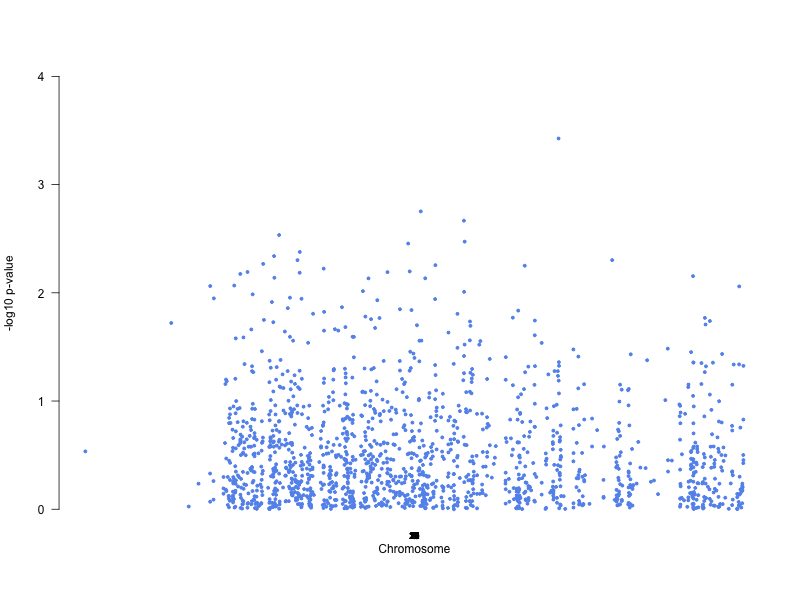

Figure 6: Manhattan plot obtained with GWAMA

```r
for(j in 1:length(runs))
{
   if(runs[j]=='lowcpgs') {
      lowCpGs = TRUE
      # Get low presence CpGs in order to exclude this from the new meta-analysis
      list.lowCpGs <- get_low_presence_CpGs(outputfiles[[j-1]], pcentMissing)
      inputfolder <- paste0(results_gwama,"/GWAMA/",  names(metafiles)[metf], "_Filtr")
      outputgwama <- paste0(outputgwama,"_Filtr")
   }

   # Create a GWAMA files for each file in meta-analysis and one file with
   # gwama meta-analysis configuration
   for ( i in 1:length(modelfiles) )
      create_GWAMA_files(results_folder,  modelfiles[i],
                         inputfolder, N[i], list.lowCpGs )

   # Execute GWAMA meta-analysis and manhattan-plot, QQ-plot and a file
   # with gwama results.
   outputfiles[[runs[j]]] <- run_GWAMA_MetaAnalysis(inputfolder,
                                                    outputgwama,
                                                    names(metafiles)[metf],
                                                    gwama.dir)
```

After getting the GWAMA results, we perform an analysis with `get_descriptives_postGWAMA` function (similar to what was done in the QC procedure but with meta-analysis results). This function adjusts p-values, annotates CpGs, and generates a file with descriptive results and plot heterogeneity distribution, SE distribution, p-values distribution, QQ-plot with lambda, and the volcano plot.

To finish we generate the ForestPlot associated to the first 30 top significative CpGs.

[figure not shown]

Figure 7: Heterogeneity distribution plot (i2)

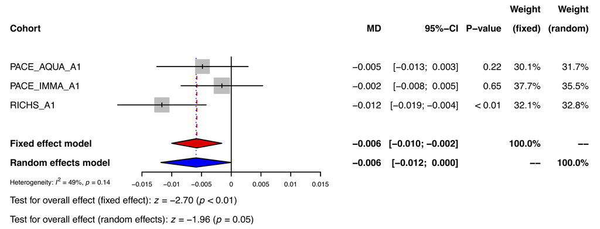

Figure 8: Forest plot for cpg22718050

```r
   # Post-metha-analysis QC --- >>> adds BN and FDR adjustment
   dataPost <- get_descriptives_postGWAMA(outputgwama,
                                          outputfiles[[runs[j]]],
                                          modelfiles,
                                          names(metafiles)[metf],
                                          artype,
                                          N[which(prefixes %in% modelfiles)] )

   # Forest-Plot
   plot_ForestPlot( dataPost, metafiles[[metf]], runs[j],
                    inputfolder, names(metafiles)[metf], files, outputgwama  )

}
```

# 6 Enrichment

## 6.1 Functional enrichment - Based on CpGs

### 6.1.1 GO and KEGG

### 6.1.2 Functional enrichment - Based on Genes

## 6.2 Molecular enrichment - Based on CpGs

### 6.2.1 Pathways with Molecular Signatures Database (MSigDB)